# Coursera Machine Learning Prediction Assignment

Peter Zale

May 21, 2016

## Introduction

Using devices such as Jawbone Up, Nike FuelBand, and Fitbit it is now possible to collect a large amount of data about personal activity relatively inexpensively. These type of devices are part of the quantified self movement – a group of enthusiasts who take measurements about themselves regularly to improve their health, to find patterns in their behavior, or because they are tech geeks. One thing that people regularly do is quantify how much of a particular activity they do, but they rarely quantify how well they do it.

In this project, your goal will be to predict the manner in which they performed the exercise using the data from accelerometers on the belt, forearm, arm, and dumbell of 6 participants. They were asked to perform barbell lifts correctly and incorrectly in 5 different ways. More information is available from the website here: http://groupware.les.inf.puc-rio.br/har (see the section on the Weight Lifting Exercise Dataset)

## Data Sets

The training data for this project are available here:

https://d396qusza40orc.cloudfront.net/predmachlearn/pml-training.csv

The test data are available here:

https://d396qusza40orc.cloudfront.net/predmachlearn/pml-testing.csv

## Processing the Data

We will first load required R packages and then load the data sets from the URLs that were provided.

```r
#Load necessary packages
library(caret)
library(rpart)
library(rattle)
library(rpart.plot)
library(repmis)
library(randomForest)
```

```r
# import the data from the URLs
#trainurl <- "https://d396qusza40orc.cloudfront.net/predmachlearn/pml-training.csv"
#testurl <- "https://d396qusza40orc.cloudfront.net/predmachlearn/pml-testing.csv"
#training <- source_data(trainurl, na.strings = c("NA", "#DIV/0!", ""), header = TRUE)
#testing <- source_data(testurl, na.strings = c("NA", "#DIV/0!", ""), header = TRUE)
# load data locally
trainingData <- read.csv("pml-training.csv", na.strings = c("NA", ""))
testingData <- read.csv("pml-testing.csv", na.strings = c("NA", ""))
```

### Data Cleaning

Now we will remove columns that contain NAs in the testing dataset. We will also remove the first 7 features since they are not needed for our prediction.

```r
features <- names(testingData[,colSums(is.na(testingData)) == 0])[8:59]

# Only use features used in testing cases.
training <- trainingData[,c(features,"classe")]
testing <- testingData[,c(features,"problem_id")]

dim(training); dim(testing);
```

```
## [1] 19622    53
```

```
## [1] 20 53
```

As you can see from the dimensions of the data sets, the cleaned data sets training and testing both have 53 columns. training has 19622 rows while testing has 20 rows.

### Subsetting the Data

```r
set.seed(12345)

inTrain <- createDataPartition(training$classe, p=0.7, list=FALSE)
training <- training[inTrain,]
testing <- training[-inTrain,]
```

### Decision Tree

```r
control <- trainControl(method = "cv", number = 5)
modFitDT <- train(classe ~ ., data = training, method = "rpart",
                   trControl = control)
print(modFitDT, digits = 4)
```

```
## CART
##
## 13737 samples
##    52 predictor
##     5 classes: 'A', 'B', 'C', 'D', 'E'
##
## No pre-processing
## Resampling: Cross-Validated (5 fold)
## Summary of sample sizes: 10989, 10990, 10990, 10989, 10990
## Resampling results across tuning parameters:
##
##   cp       Accuracy  Kappa    Accuracy SD  Kappa SD
##   0.03753  0.5161    0.37284  0.01087      0.01436
##   0.05988  0.4167    0.20950  0.07150      0.11902
##   0.11586  0.3324    0.07355  0.04394      0.06715
##
## Accuracy was used to select the optimal model using  the largest value.
## The final value used for the model was cp = 0.03753.
```

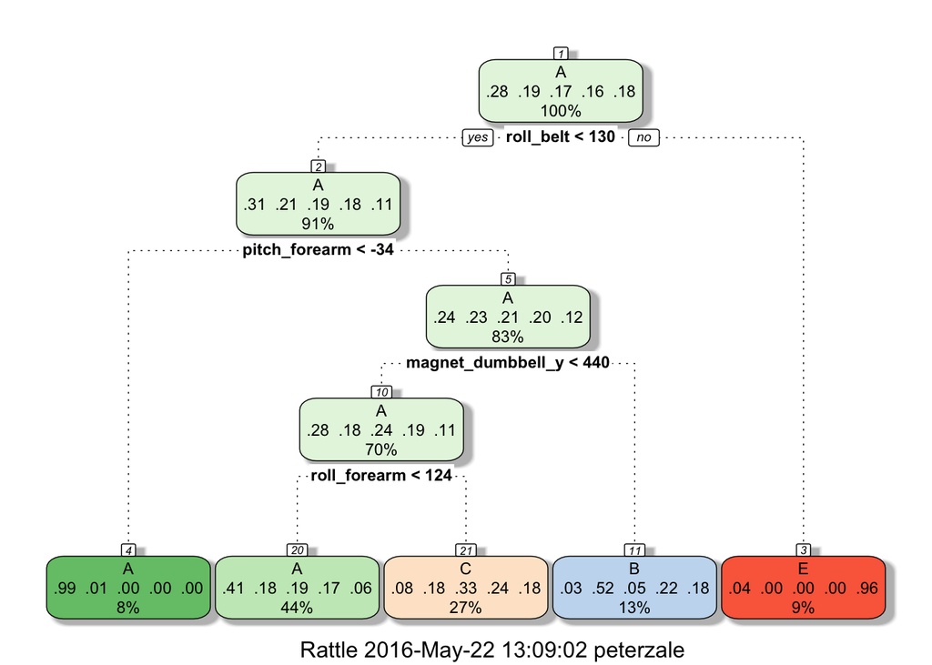

```r
fancyRpartPlot(modFitDT$finalModel)
```

```r
#prediction using testing set
predictDT <- predict(modFitDT, testing)
confusionMatrix(predictDT, testing$classe)
```

```
## Confusion Matrix and Statistics
##
##           Reference
## Prediction    A    B    C    D    E
##          A 1074  319  345  319  100
##          B   11  276   20  128   91
##          C   67  207  354  259  205
##          D    0    0    0    0    0
##          E    9    0    0    0  326
##
## Overall Statistics
##
##                Accuracy : 0.4939
##                  95% CI : (0.4785, 0.5093)
##     No Information Rate : 0.2825
##     P-Value [Acc > NIR] : < 2.2e-16
##
##                   Kappa : 0.3393
##  Mcnemar's Test P-Value : NA
##
## Statistics by Class:
##
##                      Class: A Class: B Class: C Class: D Class: E
## Sensitivity            0.9251  0.34414  0.49235   0.0000  0.45152
## Specificity            0.6328  0.92443  0.78237   1.0000  0.99734
## Pos Pred Value         0.4979  0.52471  0.32418      NaN  0.97313
## Neg Pred Value         0.9555  0.85324  0.87906   0.8282  0.89510
## Prevalence             0.2825  0.19513  0.17494   0.1718  0.17567
## Detection Rate         0.2613  0.06715  0.08613   0.0000  0.07932
## Detection Prevalence   0.5248  0.12798  0.26569   0.0000  0.08151
## Balanced Accuracy      0.7789  0.63428  0.63736   0.5000  0.72443
```

As shown in the confusion matrix, the accuracy rate is 0.5, and so the out-of-sample error rate is 0.5. That is very low so our decision tree model will not be good enough to use as a predictor. We will need to explore another option.

### Random Forest Method

```r
set.seed(12345)
modFitRF <- randomForest(classe ~ ., data = training, ntree = 1000)
```

```r
#prediction using testing set
predictRF <- predict(modFitRF, testing, type = "class")
confusionMatrix(predictRF, testing$classe)
```

```
## Confusion Matrix and Statistics
##
##           Reference
## Prediction    A    B    C    D    E
##          A 1161    0    0    0    0
##          B    0  802    0    0    0
##          C    0    0  719    0    0
##          D    0    0    0  706    0
##          E    0    0    0    0  722
##
## Overall Statistics
##
##                Accuracy : 1
##                  95% CI : (0.9991, 1)
##     No Information Rate : 0.2825
##     P-Value [Acc > NIR] : < 2.2e-16
##
##                   Kappa : 1
##  Mcnemar's Test P-Value : NA
##
## Statistics by Class:
##
##                      Class: A Class: B Class: C Class: D Class: E
## Sensitivity            1.0000   1.0000   1.0000   1.0000   1.0000
## Specificity            1.0000   1.0000   1.0000   1.0000   1.0000
## Pos Pred Value         1.0000   1.0000   1.0000   1.0000   1.0000
## Neg Pred Value         1.0000   1.0000   1.0000   1.0000   1.0000
## Prevalence             0.2825   0.1951   0.1749   0.1718   0.1757
## Detection Rate         0.2825   0.1951   0.1749   0.1718   0.1757
## Detection Prevalence   0.2825   0.1951   0.1749   0.1718   0.1757
## Balanced Accuracy      1.0000   1.0000   1.0000   1.0000   1.0000
```

### Prediction on the Testing Set

```r
predictionRF <- predict(modFitRF, testingData)
predictionRF
```

```
##  1  2  3  4  5  6  7  8  9 10 11 12 13 14 15 16 17 18 19 20
##  B  A  B  A  A  E  D  B  A  A  B  C  B  A  E  E  A  B  B  B
## Levels: A B C D E
```